# JSON FILE:-

To get the data of location history, the JSON file is downloaded from google takeout.

- A JSON file is a file that stores simple data structures and objects in JavaScript Object Notation (JSON) format, which is a standard data interchange format.
- It is primarily used for transmitting data between a web application and a server

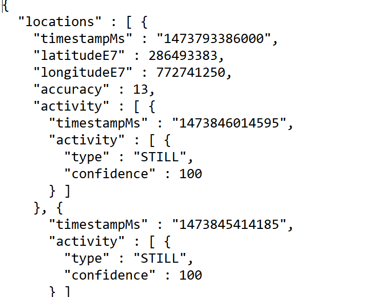

```python
from IPython.display import Image
Image(filename='json.png')
```

```python
#using
import pandas as pd
from datetime import datetime as dt
# load the google location history data
df_gps = pd.read_json('location.json')
print('There are {:,} rows in the location history dataset'.format(len(df_gps)))
```

```
There are 322,903 rows in the location history dataset
```

```python
# EXTRACTING LATITUDE,LONGITUDE AND TIMSTAMP_MS
df_gps['lat'] = df_gps['locations'].map(lambda x: x['latitudeE7'])
df_gps['lon'] = df_gps['locations'].map(lambda x: x['longitudeE7'])
df_gps['timestamp_ms'] = df_gps['locations'].map(lambda x: x['timestampMs'])

# convert lat/lon to decimalized degrees and the timestamp to date-time

df_gps['Latitude'] = df_gps['lat'] / 10.**7
df_gps['Longitude'] = df_gps['lon'] / 10.**7

#timestamps are in ISO 8601 standard

df_gps['timestamp_ms'] = df_gps['timestamp_ms'].astype(float) / 1000

#converting timestamps to datetime format

df_gps['datetime'] = df_gps['timestamp_ms'].map(lambda x: dt.fromtimestamp(x).strftime('%Y-%m-%d %H:%M:%S'))
```

```python
df_gps.head()
```

|  | locations | lat | lon | timestamp_ms | Latitude | Longitude | datetime |
| --- | --- | --- | --- | --- | --- | --- | --- |
| 0 | {'timestampMs': '1473793386000', 'latitudeE7':... | 286493383 | 772741250 | 1.473793e+09 | 28.649338 | 77.274125 | 2016-09-14 00:33:06 |
| 1 | {'timestampMs': '1473846266000', 'latitudeE7':... | 286485800 | 772737317 | 1.473846e+09 | 28.648580 | 77.273732 | 2016-09-14 15:14:26 |
| 2 | {'timestampMs': '1473905928000', 'latitudeE7':... | 286490317 | 772746167 | 1.473906e+09 | 28.649032 | 77.274617 | 2016-09-15 07:48:48 |
| 3 | {'timestampMs': '1473990648000', 'latitudeE7':... | 286478617 | 772745883 | 1.473991e+09 | 28.647862 | 77.274588 | 2016-09-16 07:20:48 |
| 4 | {'timestampMs': '1474095329000', 'latitudeE7':... | 286489033 | 772741467 | 1.474095e+09 | 28.648903 | 77.274147 | 2016-09-17 12:25:29 |

```python
# drop columns we don't need, then show a slice of the dataframe
df_gps = df_gps.drop(labels=['locations', 'timestamp_ms'], axis=1, inplace=False)
df_gps.head()
```

|  | lat | lon | Latitude | Longitude | datetime |
| --- | --- | --- | --- | --- | --- |
| 0 | 286493383 | 772741250 | 28.649338 | 77.274125 | 2016-09-14 00:33:06 |
| 1 | 286485800 | 772737317 | 28.648580 | 77.273732 | 2016-09-14 15:14:26 |
| 2 | 286490317 | 772746167 | 28.649032 | 77.274617 | 2016-09-15 07:48:48 |
| 3 | 286478617 | 772745883 | 28.647862 | 77.274588 | 2016-09-16 07:20:48 |
| 4 | 286489033 | 772741467 | 28.648903 | 77.274147 | 2016-09-17 12:25:29 |

# Finding address using geopy library

- Reverse geocoding:-It starts with a latitude & longitude point, and gives us back the corresponding street address.
- Geopy library is used for this purpose.
- Geopy is a Python 2 and 3 client for popular geocoding web services.
- Geopy is used to locate the coordinates of addresses, cities, countries, and landmarks across the globe.

```python
import geopy
from geopy.geocoders import Nominatim
from geopy.extra.rate_limiter import RateLimiter

subdf = df_gps.head(10).copy(deep=True)
#creating tuple of latitude and longitude
subdf["LatLong"] = subdf["Latitude"].map(str) + ',' + subdf["Longitude"].map(str)
subdf.head()
```

|  | lat | lon | Latitude | Longitude | datetime | LatLong |
| --- | --- | --- | --- | --- | --- | --- |
| 0 | 286493383 | 772741250 | 28.649338 | 77.274125 | 2016-09-14 00:33:06 | 28.6493383,77.274125 |
| 1 | 286485800 | 772737317 | 28.648580 | 77.273732 | 2016-09-14 15:14:26 | 28.64858,77.2737317 |
| 2 | 286490317 | 772746167 | 28.649032 | 77.274617 | 2016-09-15 07:48:48 | 28.6490317,77.2746167 |
| 3 | 286478617 | 772745883 | 28.647862 | 77.274588 | 2016-09-16 07:20:48 | 28.6478617,77.2745883 |
| 4 | 286489033 | 772741467 | 28.648903 | 77.274147 | 2016-09-17 12:25:29 | 28.6489033,77.2741467 |

# Nominatim geocoder

- Nominatim uses OpenStreetMap data to find an address for any location on the planet.
- User_Agent is an http request header that is sent with each request.
- Nominatim requires this value to be set to our application name.
- The goal is to be able to limit the number of requests per application.

```python
locator = Nominatim(user_agent="myGeocoder", timeout=10)
rgeocode = RateLimiter(locator.reverse, min_delay_seconds=0.001)
subdf['address'] = subdf['LatLong'].apply(rgeocode)

#  detailed addresses will be shown
subdf.head(10)
```

|  | lat | lon | Latitude | Longitude | datetime | LatLong | address |
| --- | --- | --- | --- | --- | --- | --- | --- |
| 0 | 286493383 | 772741250 | 28.649338 | 77.274125 | 2016-09-14 00:33:06 | 28.6493383,77.274125 | (Geeta Colony, Preet Vihar Tehsil, East Delhi,... |
| 1 | 286485800 | 772737317 | 28.648580 | 77.273732 | 2016-09-14 15:14:26 | 28.64858,77.2737317 | (Geeta Colony, Preet Vihar Tehsil, East Delhi,... |
| 2 | 286490317 | 772746167 | 28.649032 | 77.274617 | 2016-09-15 07:48:48 | 28.6490317,77.2746167 | (Geeta Colony, Preet Vihar Tehsil, East Delhi,... |
| 3 | 286478617 | 772745883 | 28.647862 | 77.274588 | 2016-09-16 07:20:48 | 28.6478617,77.2745883 | (Geeta Colony, Preet Vihar Tehsil, East Delhi,... |
| 4 | 286489033 | 772741467 | 28.648903 | 77.274147 | 2016-09-17 12:25:29 | 28.6489033,77.2741467 | (Geeta Colony, Preet Vihar Tehsil, East Delhi,... |
| 5 | 286390117 | 772658299 | 28.639012 | 77.265830 | 2016-09-17 18:08:54 | 28.6390117,77.2658299 | (Geeta Colony Road, Gandhi Nagar Tehsil, East ... |
| 6 | 286487450 | 772741817 | 28.648745 | 77.274182 | 2016-09-18 03:40:36 | 28.648745,77.2741817 | (Geeta Colony, Preet Vihar Tehsil, East Delhi,... |
| 7 | 286488367 | 772743383 | 28.648837 | 77.274338 | 2016-09-18 08:06:16 | 28.6488367,77.2743383 | (Geeta Colony, Preet Vihar Tehsil, East Delhi,... |
| 8 | 286488267 | 772743317 | 28.648827 | 77.274332 | 2016-09-18 11:20:03 | 28.6488267,77.2743317 | (Geeta Colony, Preet Vihar Tehsil, East Delhi,... |
| 9 | 286487128 | 772744513 | 28.648713 | 77.274451 | 2016-09-18 11:20:31 | 28.6487128,77.2744513 | (Geeta Colony, Preet Vihar Tehsil, East Delhi,... |

```python
latlong_col = df_gps[['Latitude','Longitude']]
print(latlong_col)
l1=latlong_col.head(20)
print(l1)
```

```
         Latitude  Longitude
0       28.649338  77.274125
1       28.648580  77.273732
2       28.649032  77.274617
3       28.647862  77.274588
4       28.648903  77.274147
...           ...        ...
322898  28.650049  77.273186
322899  28.650049  77.273186
322900  28.650049  77.273186
322901  28.650279  77.272303
322902  28.650279  77.272303

[322903 rows x 2 columns]
     Latitude  Longitude
```

[output cut: 20 more lines]

```python
# displaying first 20 locations using folium library.
import folium
map_f = folium.Map(
    location=[28.5011226, 77.4099794],
    zoom_start=12)
l1.apply(lambda row:folium.Marker(location=[row["Latitude"], row["Longitude"]]).add_to(map_f), axis=1)
map_f.save("map_f.html")
```

[figure not shown]

```python
from IPython.display import Image
Image(filename='map.png')
```